# GLM para dados contínuos

Aline Bueno, José Daniel, Juliana Moureira

## 1 1. Introdução

O objetivo deste relatório é modelar a Captura-por-Unidade-de-Esforço (CPUE) das principais espécies-alvo da pesca. Buscamos entender como a CPUE é influenciada por um conjunto de fatores oceanográficos (ex: temperatura da superfície do mar - `sst`, salinidade - `sal`), espaço-temporais (Mês, Latitude, Longitude) e fatores da própria pescaria (removidos durante a seleção).

Foi utilizado um Modelo Linear Generalizado (GLM) para dados contínuos, seguindo um processo de seleção e diagnóstico de modelo.

## 2 2. Metodologia

### 2.1 2.1. Carga e Preparação dos Dados

Os dados foram carregados e as variáveis categóricas (`Ano`,`Mes`, `Barco`) foram convertidas em fatores. As espécies-alvo foram agregadas e a CPUE foi calculada como a captura total das espécies-alvo dividida pelo número de anzóis (`N_anzol`)

```r
# 2. Importando os dados (ajuste o caminho se necessário)
## Definindo diretório base
setwd("C:/Users/Aline Bueno/Desktop/Mestrado/Disciplinas/Modelos Lineares Geralizado e Aditivos para Dados Ecológicos/ECL0072-GLM_GAM-gh-pages")
dados <- readRDS("Dados/fisheries.rds")

# 3.1. Transformando variáveis categóricas
dados[, c("Ano", "Mes", "Barco")] <- lapply(dados[, c("Ano", "Mes", "Barco")], factor)

# 3.2. Espécies-alvo e cálculo da CPUE
especies_alvo <- c("Thunnus_albacares", "Thunnus_atlanticus",
                   "Katsuwonus_pelamis", "Prionace_glauca")

dados <- dados %>%
  rowwise() %>%
  mutate(
    Captura_Alvo = sum(c_across(all_of(especies_alvo))),
    CPUE = Captura_Alvo / N_anzol
  ) %>%
  data.frame()
```

### 2.2 2.2. Análise Exploratória (EDA)

A análise exploratória da variável resposta (CPUE) foi crucial para a escolha do modelo.

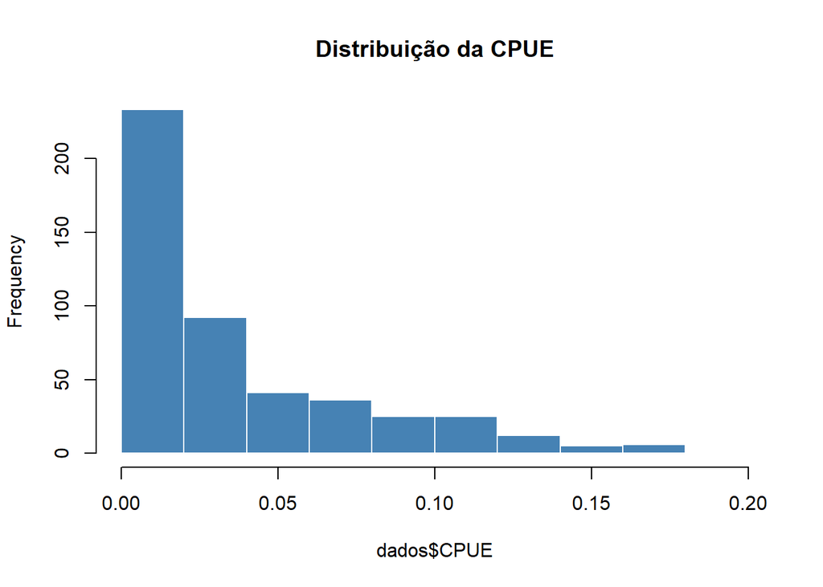

Gráfico 1: Distribuição da CPUE. Nota-se forte assimetria positiva.

```r
# 4. Explorando a CPUE
hist(dados$CPUE, main = "Distribuição da CPUE", col = "steelblue", border = "white")
```

O Gráfico 1 mostra uma forte **assimetria positiva** (à direita), com a maioria dos valores concentrada próxima de zero e uma cauda longa de valores altos. Este padrão descarta o uso de um modelo linear simples (baseado na distribuição Normal).

A proporção de **zeros exatos** também foi verificada:

```r
mean(dados$CPUE == 0)
```

```
## [1] 0.00210084
```

Com apenas **0.21%** de zeros, concluímos que os dados não são inflacionados de zeros, e uma abordagem de adicionar uma pequena constante para usar as famílias `Gamma` ou `Log-Normal` é apropriada.

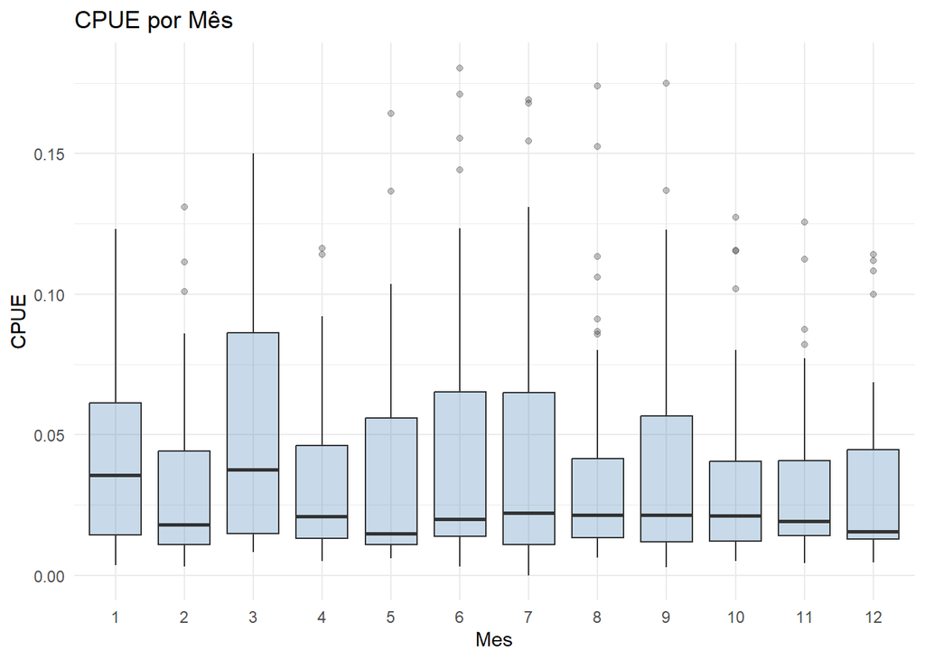

Gráfico 2: Relação da CPUE com Mês (Sazonalidade).

```r
# 4.1. CPUE vs Mês
ggplot(dados, aes(x = Mes, y = CPUE)) +
  geom_boxplot(fill = 'steelblue', alpha = 0.3) +
  theme_minimal() +
  labs(title = "CPUE por Mês")
```

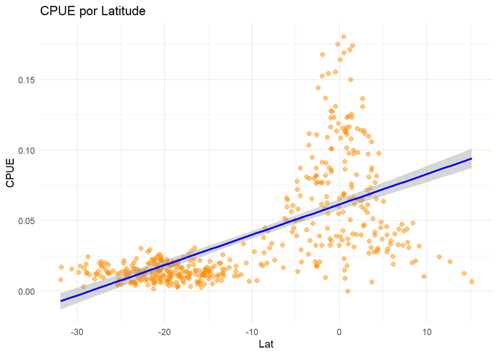

Gráfico 3: Relação da CPUE com Latitude. Nota-se uma tendência positiva e heterocedasticidade.

```r
# 4.2. CPUE vs Latitude
ggplot(dados, aes(x = Lat, y = CPUE)) +
  geom_point(size = 2, col = 'darkorange', alpha = 0.5) +
  geom_smooth(method = "lm", col = 'blue') +
  theme_minimal() +
  labs(title = "CPUE por Latitude")
```

### 2.3 2.3. Abordagem de Modelagem (GLM)

Com base na assimetria e heterocedasticidade, escolhemos um GLM.

1. **Tratamento de Zeros:** Adicionamos uma pequena constante à CPUE (`CPUE2`).
2. **Comparação de Famílias:** Comparamos um GLM com família `Gamma(link="log")` (adequado para heterocedasticidade) contra um modelo `gaussian` na CPUE log-transformada (`CPUE2_log`).
3. **Correção de Colinearidade:** O modelo inicial apresentou alta colinearidade estrutural (VIF > 70) na interação `Lat * Long`. Para corrigir isso, as variáveis `Lat` e `Long` foram **centradas na média** antes da modelagem.

```r
# 5. Preparando os dados para o modelo
dados$CPUE2 <- dados$CPUE + (0.1 * median(dados$CPUE[dados$CPUE > 0]))
dados$CPUE2_log <- log(dados$CPUE2)

# 5.1. CORREÇÃO: Centrando variáveis da interação
dados$Lat_c <- as.numeric(scale(dados$Lat, center = TRUE, scale = FALSE))
dados$Long_c <- as.numeric(scale(dados$Long, center = TRUE, scale = FALSE))
```

## 3 3. Resultados

### 3.1 3.1. Seleção do Modelo

Primeiro, comparamos os modelos Gamma e Log-Normal (Gaussian) usando AIC.

```r
# 6. Ajustando os modelos com variáveis centradas
modelo_CPUE_G_c <- glm(CPUE2 ~ Mes + Lat_c * Long_c + sst + sal + chla +
                         depth + dlm + il + Barco,
                       family = Gamma(link = "log"), data = dados)

modelo_CPUE_LN_c <- glm(CPUE2_log ~ Mes + Lat_c * Long_c + sst + sal + chla +
                          depth + dlm + il + Barco,
                        family = gaussian, data = dados)

# 7. Comparando AIC
AIC(modelo_CPUE_G_c, modelo_CPUE_LN_c)
```

```
##                  df        AIC
## modelo_CPUE_G_c  32 -2512.1360
## modelo_CPUE_LN_c 32   931.0878
```

O modelo **Gamma (`modelo_CPUE_G_c`)** apresentou um AIC **incomparavelmente inferior** (-2512.1) ao do Log-Normal (931.1), sendo a escolha definitiva.

Em seguida, avaliamos a colinearidade do `modelo_CPUE_G_c` (já corrigido da colinearidade estrutural).

```r
check_collinearity(modelo_CPUE_G_c)
```

```
## # Check for Multicollinearity
##
## Low Correlation
##
##          Term  VIF    VIF 95% CI adj. VIF Tolerance Tolerance 95% CI
##         Lat_c 1.08 [1.03,  1.27]     1.04      0.92     [0.79, 0.97]
##        Long_c 1.09 [1.03,  1.27]     1.05      0.91     [0.79, 0.97]
##           sst 3.03 [2.65,  3.50]     1.74      0.33     [0.29, 0.38]
##           sal 1.72 [1.54,  1.95]     1.31      0.58     [0.51, 0.65]
##         depth 3.14 [2.74,  3.63]     1.77      0.32     [0.28, 0.36]
##            il 1.07 [1.02,  1.27]     1.03      0.93     [0.79, 0.98]
##  Lat_c:Long_c 1.09 [1.03,  1.27]     1.04      0.92     [0.79, 0.97]
##
## Moderate Correlation
##
##  Term  VIF    VIF 95% CI adj. VIF Tolerance Tolerance 95% CI
##   Mes 8.42 [7.21,  9.87]     1.10      0.12     [0.10, 0.14]
##  chla 5.96 [5.12,  6.96]     2.44      0.17     [0.14, 0.20]
##   dlm 7.12 [6.11,  8.33]     2.67      0.14     [0.12, 0.16]
##
## High Correlation
##
##   Term   VIF    VIF 95% CI adj. VIF Tolerance Tolerance 95% CI
##  Barco 10.62 [9.07, 12.47]     1.13      0.09     [0.08, 0.11]
```

O diagnóstico de VIF (Variance Inflation Factor) revelou colinearidade severa na variável `Barco` (VIF = 10.62). Testamos um modelo sem esta variável para avaliar se ela era de fato necessária.

```r
# Modelo final sem 'Barco'
modelo_final <- update(modelo_CPUE_G_c, . ~ . - Barco)

# Comparando o AIC
AIC(modelo_CPUE_G_c, modelo_final)
```

```
##                 df       AIC
## modelo_CPUE_G_c 32 -2512.136
## modelo_final    22 -2522.684
```

O modelo sem `Barco` (`modelo_final`) apresentou um AIC **ainda melhor** (-2522.7 vs -2512.1), indicando que ele é mais parcimonioso e tem melhor ajuste. Esta variável estava mais atrapalhando (pela colinearidade) do que ajudando o modelo.

**O `modelo_final` foi selecionado para a análise.**

### 3.2 3.2. Diagnóstico do Modelo Final

A colinearidade do `modelo_final` foi verificada:

```r
check_collinearity(modelo_final)
```

```
## # Check for Multicollinearity
##
## Low Correlation
##
##          Term  VIF   VIF 95% CI adj. VIF Tolerance Tolerance 95% CI
##           Mes 4.03 [3.48, 4.69]     1.07      0.25     [0.21, 0.29]
##         Lat_c 1.04 [1.01, 1.36]     1.02      0.96     [0.73, 0.99]
##        Long_c 1.07 [1.02, 1.28]     1.03      0.93     [0.78, 0.98]
##           sst 1.54 [1.39, 1.75]     1.24      0.65     [0.57, 0.72]
##           sal 1.33 [1.22, 1.51]     1.15      0.75     [0.66, 0.82]
##         depth 2.15 [1.90, 2.47]     1.47      0.47     [0.41, 0.53]
##            il 1.05 [1.01, 1.32]     1.03      0.95     [0.76, 0.99]
##  Lat_c:Long_c 1.05 [1.01, 1.32]     1.03      0.95     [0.76, 0.99]
##
## Moderate Correlation
##
##  Term  VIF   VIF 95% CI adj. VIF Tolerance Tolerance 95% CI
##  chla 5.58 [4.79, 6.53]     2.36      0.18     [0.15, 0.21]
##   dlm 6.36 [5.45, 7.46]     2.52      0.16     [0.13, 0.18]
```

**Todos os VIFs estão agora em níveis aceitáveis (< 10)**. A colinearidade moderada restante (`chla` e `dlm`, VIF 5-6) é esperada, pois são variáveis oceanográficas correlacionadas.

Os resíduos simulados (DHARMa) foram avaliados:

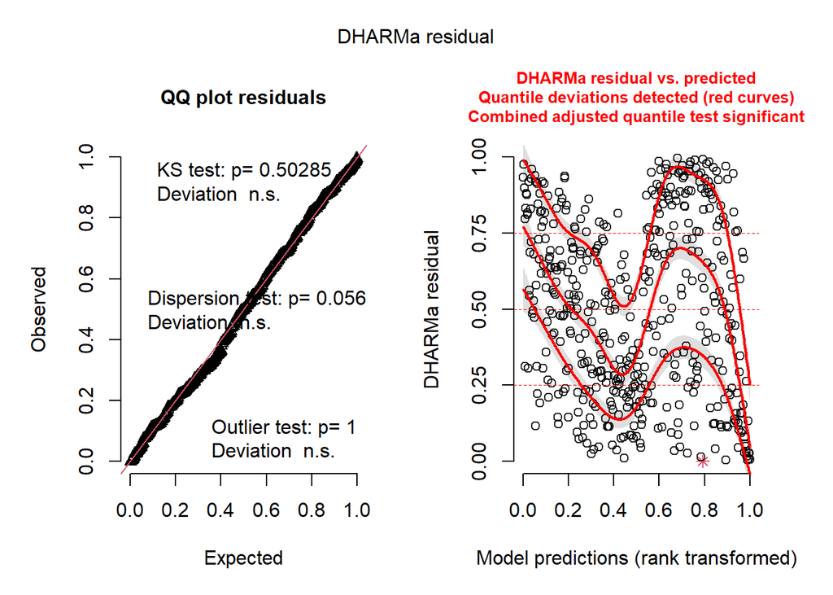

```r
# (Usando n=500 para um gráfico mais robusto)
res_final <- simulateResiduals(modelo_final, n = 500)
plot(res_final)
```

### 3.3 3.3. Interpretação do Modelo Final

O `summary()` do `modelo_final` fornece os efeitos de cada preditor.

```r
summary(modelo_final)
```

```
##
## Call:
## glm(formula = CPUE2 ~ Mes + Lat_c + Long_c + sst + sal + chla +
##     depth + dlm + il + Lat_c:Long_c, family = Gamma(link = "log"),
##     data = dados)
##
## Coefficients:
##                Estimate Std. Error t value Pr(>|t|)
## (Intercept)  -3.698e+00  3.910e-01  -9.458   <2e-16 ***
## Mes2          7.929e-02  1.374e-01   0.577   0.5642
## Mes3          2.936e-01  1.497e-01   1.961   0.0505 .
## Mes4          7.819e-02  1.500e-01   0.521   0.6025
## Mes5          1.113e-01  1.558e-01   0.715   0.4752
## Mes6          2.846e-01  1.421e-01   2.003   0.0458 *
## Mes7          1.514e-01  1.424e-01   1.063   0.2883
## Mes8          1.320e-01  1.435e-01   0.920   0.3578
## Mes9          1.991e-01  1.398e-01   1.424   0.1550
## Mes10         6.556e-02  1.415e-01   0.463   0.6433
## Mes11         1.070e-01  1.405e-01   0.762   0.4466
## Mes12         6.936e-02  1.426e-01   0.486   0.6269
## Lat_c         6.088e-02  2.333e-03  26.098   <2e-16 ***
## Long_c       -1.070e-02  6.634e-03  -1.612   0.1076
## sst           1.330e-02  1.535e-02   0.866   0.3868
## sal          -5.201e-03  6.017e-03  -0.864   0.3878
## chla          1.904e+00  1.057e+00   1.802   0.0722 .
## depth        -1.154e-05  3.577e-05  -0.323   0.7471
## dlm          -7.607e-03  4.251e-03  -1.789   0.0742 .
## il            6.901e-02  7.262e-02   0.950   0.3424
## Lat_c:Long_c  7.423e-04  5.651e-04   1.314   0.1896
## ---
## Signif. codes:  0 '***' 0.001 '**' 0.01 '*' 0.05 '.' 0.1 ' ' 1
##
## (Dispersion parameter for Gamma family taken to be 0.3076053)
##
##     Null deviance: 366.91  on 475  degrees of freedom
## Residual deviance: 155.85  on 455  degrees of freedom
## AIC: -2522.7
##
## Number of Fisher Scoring iterations: 8
```

## 4 4. Visualização dos Efeitos Significativos

Gráficos de predição ajudam a visualizar os resultados do `summary()`.

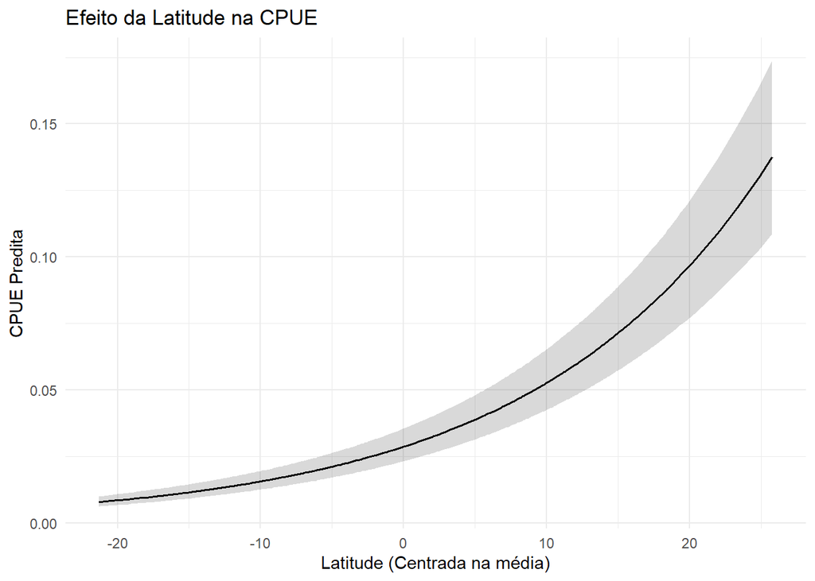

Gráfico 5: Efeito da Latitude (centrada) na CPUE predita.

```r
# Efeito da Latitude
pred_lat <- ggpredict(modelo_final, terms = "Lat_c [all]")
plot(pred_lat) +
  labs(title = "Efeito da Latitude na CPUE",
       x = "Latitude (Centrada na média)", y = "CPUE Predita") +
  theme_minimal()
```

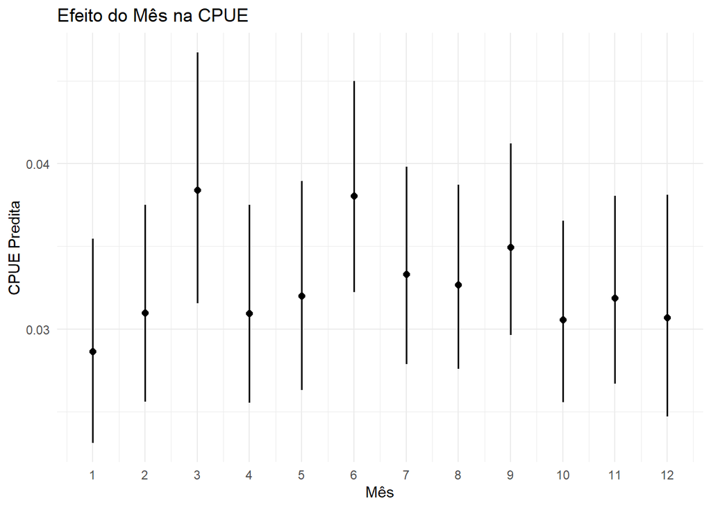

Gráfico 6: Efeito do Mês na CPUE predita.

```r
# Efeito do Mês
pred_mes <- ggpredict(modelo_final, terms = "Mes")
plot(pred_mes) +
  labs(title = "Efeito do Mês na CPUE",
       x = "Mês", y = "CPUE Predita") +
  theme_minimal()
```

O Gráfico 5 ilustra a forte tendência positiva da Latitude, e o Gráfico 6 mostra os picos sazonais em Março e Junho.

## 5 5. Conclusão

O GLM com família **Gamma** (`AIC = -2522.7`) foi o modelo mais robusto para explicar a CPUE.